# EDA Case Competition

RJ Hazen, Marcus Needham, Hunter Nilsen

2024-10-05

# Capstone Final Project - Predictive Maintenece: Swire Coca-Cola

## Introduction

This exploratory data analysis (EDA) focuses on understanding machine breakdowns and maintenance patterns in Swire Coca-Cola’s production plants. The data comes from the Internal Warehouse Controller (IWC) system, which tracks machine downtimes, repairs, and maintenance activities across multiple locations.

### Problem Statement:

Swire Coca-Cola faces significant losses, around $60 million annually, due to unplanned machine breakdowns. The company wants to reduce these losses by identifying patterns in downtime and developing a predictive maintenance model that can foresee breakdowns before they happen. This would allow the company to better plan for repairs and minimize downtime.

### Objectives:

The key objectives of this analysis are to: - Analyze the distribution of machine downtime across different plants and machines. - Compare the effectiveness of preventive vs. unplanned maintenance. - Explore how downtime impacts productivity. - Identify any seasonal or time-based patterns in breakdowns. - Gather insights that will help build a predictive maintenance model to reduce future downtime.

This EDA will lay the groundwork for more advanced analysis aimed at optimizing maintenance schedules and improving production efficiency.

## Questions

1. **Downtime Distribution and Patterns**
   - What is the distribution of downtime (in minutes) across different plants and machines?
2. **Predictive Maintenance Insights**
   - Which machines or parts are most prone to breakdowns? (Using `EQUIPMENT_ID` and `MAINTENANCE_ITEM`)
3. **Maintenance Type and Effectiveness**
   - What percentage of maintenance tasks are preventive (planned) versus corrective (unplanned)? Does preventive maintenance reduce unplanned downtime?
4. **Operational Impact**
   - What is the overall impact of downtime on productivity (based on `ACTUAL_WORK_IN_MINUTES`)? Can we quantify the opportunity cost per machine or plant?
5. **Temporal Analysis**
   - Are there any seasonal trends in downtime frequency (e.g., more breakdowns during specific months or seasons)?

## Load Libraries

```r
library(tidyverse)
```

```r
library(ggplot2)
library(corrplot)
```

## Read Data/View Structure

```r
data <- read.csv("IWC_Work_Orders_Extract.csv")

# Check the structure of the dataset
str(data)
```

```
## 'data.frame':    1427264 obs. of  25 variables:
##  $ ORDER_ID                       : num  7.06e+08 7.04e+08 7.04e+08 7.04e+08 7.05e+08 ...
##  $ PLANT_ID                       : chr  "G812" "G812" "G812" "G812" ...
##  $ PRODUCTION_LOCATION            : chr  "ROMA" "ROMA" "ROMA" "ROMA" ...
##  $ EXECUTION_START_DATE           : chr  "2024-05-04" "2022-09-13" "2022-12-21" "2022-07-04" ...
##  $ EXECUTION_FINISH_DATE          : chr  "2024-05-12" "2022-09-13" "2022-12-21" "2022-07-04" ...
##  $ ACTUAL_START_TIME              : chr  "06:00:00.000" "06:00:00.000" "07:00:00.000" "06:00:00.000" ...
##  $ ACTUAL_FINISH_TIME             : chr  "23:04:08.000" "17:17:24.000" "07:00:00.000" "06:00:00.000" ...
##  $ ACTUAL_WORK_IN_MINUTES         : num  390 420 30 60 120 18 480 30 30 30 ...
##  $ MAINTENANCE_PLAN               : chr  "" "" "" "" ...
##  $ MAINTENANCE_ITEM               : int  NA NA NA NA NA 40534 NA NA NA NA ...
##  $ MAINTENANCE_ACTIVITY_TYPE      : chr  "Unplanned" "Unplanned" "Unplanned" "Unplanned" ...
##  $ ORDER_DESCRIPTION              : chr  "L2 GEARBOX LEAK (SEE ATTACHED)" "LINE 3 CONVEYOR AT CAN CODER" "BROKEN CONVEYOR RAIL" "LINE 3 CONVEYOR" ...
##  $ MAINTENANCE_TYPE_DESCRIPTION   : chr  "Corrective Maintenance Order" "Corrective Maintenance Order" "Corrective Maintenance Order" "Corrective Maintenance Order" ...
##  $ FUNCTIONAL_LOC                 : chr  "G812-PRD-L15-L03-L030-020" "G812-PRD-L15-L03-L030-020" "G812-PRD-L15-L03-L030-020" "G812-PRD-L15-L03-L030-020" ...
##  $ FUNCTIONAL_AREA_NODE_1_MODIFIED: chr  "PRODUCTION" "PRODUCTION" "PRODUCTION" "PRODUCTION" ...
##  $ FUNCTIONAL_AREA_NODE_2_MODIFIED: chr  "G812 PRD FILLER_ROTARY_CAN" "G812 PRD FILLER_ROTARY_CAN" "G812 PRD FILLER_ROTARY_CAN" "G812 PRD FILLER_ROTARY_CAN" ...
##  $ FUNCTIONAL_AREA_NODE_3_MODIFIED: chr  "G812 PRD FILLER_ROTARY_CAN LINE 3" "G812 PRD FILLER_ROTARY_CAN LINE 3" "G812 PRD FILLER_ROTARY_CAN LINE 3" "G812 PRD FILLER_ROTARY_CAN LINE 3" ...
##  $ FUNCTIONAL_AREA_NODE_4_MODIFIED: chr  "CONVEYOR" "CONVEYOR" "CONVEYOR" "CONVEYOR" ...
##  $ FUNCTIONAL_AREA_NODE_5_MODIFIED: chr  "FULL CAN CONVEYOR" "FULL CAN CONVEYOR" "FULL CAN CONVEYOR" "FULL CAN CONVEYOR" ...
##  $ EQUIPMENT_ID                   : int  300126812 300126812 300126812 300126812 300001088 300001088 300001088 300001033 300001033 300001033 ...
##  $ EQUIPMENT_DESC                 : chr  "FULL CAN CONVEYOR (FC41B)" "FULL CAN CONVEYOR (FC41B)" "FULL CAN CONVEYOR (FC41B)" "FULL CAN CONVEYOR (FC41B)" ...
##  $ EQUIP_CAT_DESC                 : chr  "Machines" "Machines" "Machines" "Machines" ...
##  $ EQUIP_START_UP_DATE            : chr  "2020-04-22" "2020-04-22" "2020-04-22" "2020-04-22" ...
##  $ EQUIP_VALID_FROM               : chr  "2020-02-10" "2020-02-10" "2020-02-10" "2020-02-10" ...
##  $ EQUIP_VALID_TO                 : chr  "9999-12-31" "9999-12-31" "9999-12-31" "9999-12-31" ...
```

```r
# Summary of the data
summary(data)
```

```
##     ORDER_ID           PLANT_ID         PRODUCTION_LOCATION
##  Min.   :1.000e+08   Length:1427264     Length:1427264
##  1st Qu.:4.023e+08   Class :character   Class :character
##  Median :7.044e+08   Mode  :character   Mode  :character
##  Mean   :4.561e+10
##  3rd Qu.:1.002e+09
##  Max.   :9.000e+11
##
##  EXECUTION_START_DATE EXECUTION_FINISH_DATE ACTUAL_START_TIME
##  Length:1427264       Length:1427264        Length:1427264
##  Class :character     Class :character      Class :character
##  Mode  :character     Mode  :character      Mode  :character
##
##
##
##
##  ACTUAL_FINISH_TIME ACTUAL_WORK_IN_MINUTES MAINTENANCE_PLAN   MAINTENANCE_ITEM
##  Length:1427264     Min.   :     0.0       Length:1427264     Min.   : 39801
##  Class :character   1st Qu.:    12.0       Class :character   1st Qu.: 41046
##  Mode  :character   Median :    48.0       Mode  :character   Median :112995
##                     Mean   :    88.6                          Mean   :115847
##                     3rd Qu.:    90.0                          3rd Qu.:134702
##                     Max.   :330184.8                          Max.   :346352
##                                                               NA's   :1274670
##  MAINTENANCE_ACTIVITY_TYPE ORDER_DESCRIPTION  MAINTENANCE_TYPE_DESCRIPTION
##  Length:1427264            Length:1427264     Length:1427264
##  Class :character          Class :character   Class :character
##  Mode  :character          Mode  :character   Mode  :character
##
##
##
##
##  FUNCTIONAL_LOC     FUNCTIONAL_AREA_NODE_1_MODIFIED
##  Length:1427264     Length:1427264
##  Class :character   Class :character
##  Mode  :character   Mode  :character
##
##
##
##
```

[output cut: 17 more lines]

```
##  Min.   :200087110   Length:1427264     Length:1427264     Length:1427264
##  1st Qu.:300009161   Class :character   Class :character   Class :character
##  Median :300017751   Mode  :character   Mode  :character   Mode  :character
##  Mean   :300260910
##  3rd Qu.:300026939
##  Max.   :400029000
##  NA's   :1135469
##  EQUIP_VALID_FROM   EQUIP_VALID_TO
##  Length:1427264     Length:1427264
##  Class :character   Class :character
##  Mode  :character   Mode  :character
##
##
##
##
```

```r
# Display the first few rows
head(data)
```

```
##    ORDER_ID PLANT_ID PRODUCTION_LOCATION EXECUTION_START_DATE
## 1 705642457     G812                ROMA           2024-05-04
## 2 704191697     G812                ROMA           2022-09-13
## 3 704466547     G812                ROMA           2022-12-21
## 4 703834477     G812                ROMA           2022-07-04
## 5 704661125     G291               MONZA           2023-03-15
## 6 704948720     G291               MONZA           2023-09-08
##   EXECUTION_FINISH_DATE ACTUAL_START_TIME ACTUAL_FINISH_TIME
## 1            2024-05-12      06:00:00.000       23:04:08.000
## 2            2022-09-13      06:00:00.000       17:17:24.000
## 3            2022-12-21      07:00:00.000       07:00:00.000
## 4            2022-07-04      06:00:00.000       06:00:00.000
## 5            2023-03-15      07:00:00.000       07:00:00.000
## 6            2023-09-08      07:00:00.000       07:00:00.000
##   ACTUAL_WORK_IN_MINUTES MAINTENANCE_PLAN MAINTENANCE_ITEM
```

[output cut: 48 more lines]

## Check NA’s

```r
# Check for missing values
colSums(is.na(data))
```

```
##                        ORDER_ID                        PLANT_ID
##                               0                               0
##             PRODUCTION_LOCATION            EXECUTION_START_DATE
##                               0                               0
##           EXECUTION_FINISH_DATE               ACTUAL_START_TIME
##                               0                               0
##              ACTUAL_FINISH_TIME          ACTUAL_WORK_IN_MINUTES
##                               0                               0
##                MAINTENANCE_PLAN                MAINTENANCE_ITEM
##                               0                         1274670
##       MAINTENANCE_ACTIVITY_TYPE               ORDER_DESCRIPTION
##                               0                               0
##    MAINTENANCE_TYPE_DESCRIPTION                  FUNCTIONAL_LOC
##                               0                               0
## FUNCTIONAL_AREA_NODE_1_MODIFIED FUNCTIONAL_AREA_NODE_2_MODIFIED
##                               0                               0
## FUNCTIONAL_AREA_NODE_3_MODIFIED FUNCTIONAL_AREA_NODE_4_MODIFIED
##                               0                               0
## FUNCTIONAL_AREA_NODE_5_MODIFIED                    EQUIPMENT_ID
##                               0                         1135469
##                  EQUIPMENT_DESC                  EQUIP_CAT_DESC
##                               0                               0
##             EQUIP_START_UP_DATE                EQUIP_VALID_FROM
##                               0                               0
##                  EQUIP_VALID_TO
##                               0
```

## Distribution of Downtime (Minutes)

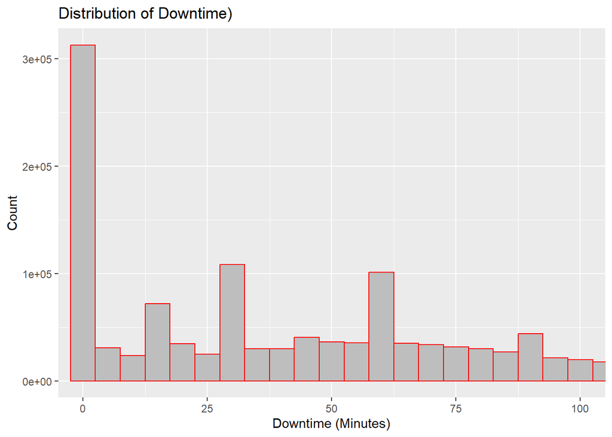

```r
# Plot downtime distribution
# Zoom in on downtimes below 100 minutes
ggplot(data, aes(x = ACTUAL_WORK_IN_MINUTES)) +
  geom_histogram(binwidth = 5, fill = "gray", color = "red") +
  coord_cartesian(xlim = c(0, 100)) +
  labs(title = "Distribution of Downtime)",
       x = "Downtime (Minutes)",
       y = "Count")
```

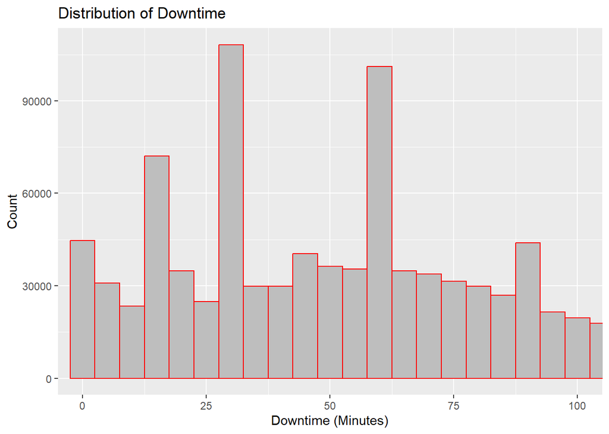

```r
### Removing 0 downtime values...
# Filter out zero downtime
non_zero_downtime <- data %>% filter(ACTUAL_WORK_IN_MINUTES > 0)

# Plot again
ggplot(non_zero_downtime, aes(x = ACTUAL_WORK_IN_MINUTES)) +
  geom_histogram(binwidth = 5, fill = "gray", color = "red") +
  coord_cartesian(xlim = c(0, 100)) +
  labs(title = "Distribution of Downtime",
       x = "Downtime (Minutes)",
       y = "Count")
```

## Distribution of Working Time (Minutes)

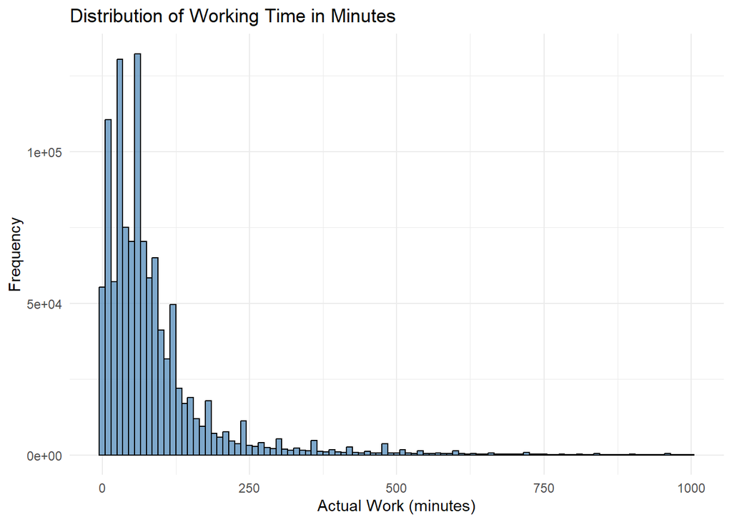

```r
# Remove extreme outliers for better visualization (e.g., work longer than 1000 minutes)
non_zero_downtime_filtered <- non_zero_downtime %>%
  filter(ACTUAL_WORK_IN_MINUTES <= 1000)  # Adjust threshold based on data distribution

# Plot after filtering outliers
ggplot(non_zero_downtime_filtered, aes(x = ACTUAL_WORK_IN_MINUTES)) +
  geom_histogram(binwidth = 10, fill = "steelblue", color = "black", alpha = 0.7) +
  labs(title = "Distribution of Working Time in Minutes",
       x = "Actual Work (minutes)",
       y = "Frequency") +
  theme_minimal()
```

**Insights:** Removing extreme outliers (>1000 minutes) helps to focus the analysis on the more common downtimes, which tend to fall below this threshold. This allows us to better understand the typical maintenance efforts, as excessively long downtimes are rare and can skew the overall distribution. Most of the downtimes are concentrated between 0 and 1000 minutes, reflecting standard repair times across machines.

## Work Orders by Plants

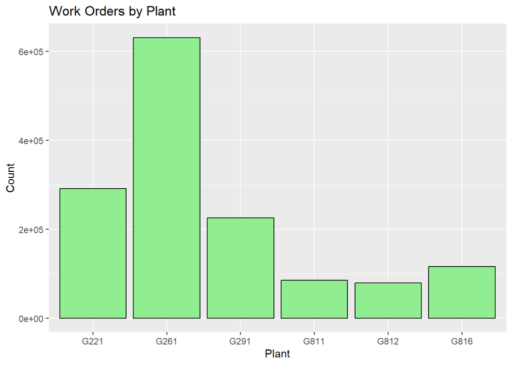

```r
# Plot number of work orders by plant
ggplot(data, aes(x = PLANT_ID)) +
  geom_bar(fill = "lightgreen", color = "black") +
  labs(title = "Work Orders by Plant", x = "Plant", y = "Count")
```

*Insights** The bar chart showing work orders by plant highlights a significant disparity in maintenance activity across locations. Plant G261 stands out with the highest number of work orders, far exceeding the other plants. This suggests that G261 may be facing more frequent breakdowns or has a larger operation requiring more maintenance. Plants G221 and G291 also have notable volumes, while Plants G811, G812, and G816 have much fewer work orders. This variation may be due to differences in machine age, operational scale, or maintenance practices. Addressing the high volume at G261 and optimizing maintenance at the other plants could help improve overall operational efficiency.

## Time to Resolve Orders by Plants

```r
# Calculate mean and median of downtime per location
avg_downtime_by_location <- data %>%
  group_by(PLANT_ID) %>%
  summarize(
    mean_downtime = mean(ACTUAL_WORK_IN_MINUTES, na.rm = TRUE),
    median_downtime = median(ACTUAL_WORK_IN_MINUTES, na.rm = TRUE),
    count = n()
  ) %>%
  arrange(desc(mean_downtime))

# View the result
print(avg_downtime_by_location)
```

```
## # A tibble: 6 × 4
##   PLANT_ID mean_downtime median_downtime  count
##   <chr>            <dbl>           <dbl>  <int>
## 1 G221             100.             60   290975
## 2 G291              94.8            44   225279
## 3 G261              94.1            54   630903
## 4 G811              65.7             3.6  84694
## 5 G816              60.7            31.2 116303
## 6 G812              50.1            18    79110
```

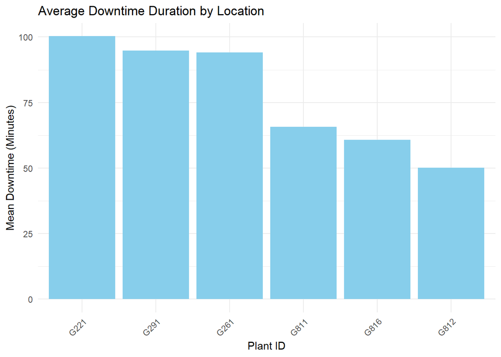

```r
# Plot average downtime by location
ggplot(avg_downtime_by_location, aes(x = reorder(PLANT_ID, -mean_downtime), y = mean_downtime)) +
  geom_bar(stat = "identity", fill = "skyblue") +
  theme_minimal() +
  labs(
    title = "Average Downtime Duration by Location",
    x = "Plant ID",
    y = "Mean Downtime (Minutes)"
  ) +
  theme(axis.text.x = element_text(angle = 45, hjust = 1))
```

**Insights:** The mean downtime across plants provides valuable context when viewed alongside the number of work orders by plant. This comparison helps identify whether higher downtime aligns with a larger volume of work orders, or if certain plants are experiencing inefficiencies in resolving issues. For example, a plant with fewer work orders but longer downtimes may suggest operational challenges or less efficient maintenance processes compared to plants with similar or higher workloads but shorter downtimes.

## Work Orders by Equipment ID

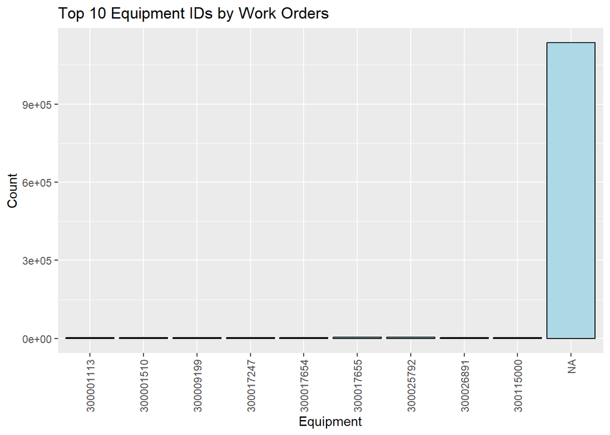

```r
# Convert EQUIPMENT_ID to factor
data$EQUIPMENT_ID <- as.factor(data$EQUIPMENT_ID)

# Find top 10 equipment IDs with the most work orders
top_equipment <- data %>%
  count(EQUIPMENT_ID) %>%
  top_n(10, n)

# Filter the dataset for the top 10 equipment IDs
top_data <- data %>%
  filter(EQUIPMENT_ID %in% top_equipment$EQUIPMENT_ID)

# Plot the top 10 equipment IDs
ggplot(top_data, aes(x = EQUIPMENT_ID)) +
  geom_bar(fill = "lightblue", color = "black") +
  labs(title = "Top 10 Equipment IDs by Work Orders",
       x = "Equipment",
       y = "Count") +
  theme(axis.text.x = element_text(angle = 90, vjust = 0.5, hjust=1))
```

**Insights** The bar chart of the top 10 equipment IDs by work orders reveals a significant data quality issue, with a large number of work orders associated with “NA” values, indicating missing or improperly recorded equipment IDs. This suggests that a substantial portion of the equipment data is incomplete, which could hinder accurate maintenance tracking. The remaining equipment IDs show a relatively even distribution of work orders, with no single piece of equipment standing out as a major contributor. Addressing the “NA” issue would provide more reliable insights and help identify which machines are responsible for the most maintenance activity, leading to better maintenance strategies.